# second week: Introduction to R and Rstudio

Mobile Data

Yasmin Sarcheshmehpour 94109827

# تمرین سری دوم: تلفن همراه شناسی!

```r
library(readr)
library(ggplot2)
library(magrittr)
library(dplyr)
mobile = read_csv("mobile_data.csv")
```

۱. کدام شرکت بیشترین تعداد گوشی را تولید کرده است؟ نمودار ستونی ۲۰ شرکت برتر بر حسب تعداد گوشی تولید کرده را رسم کنید.

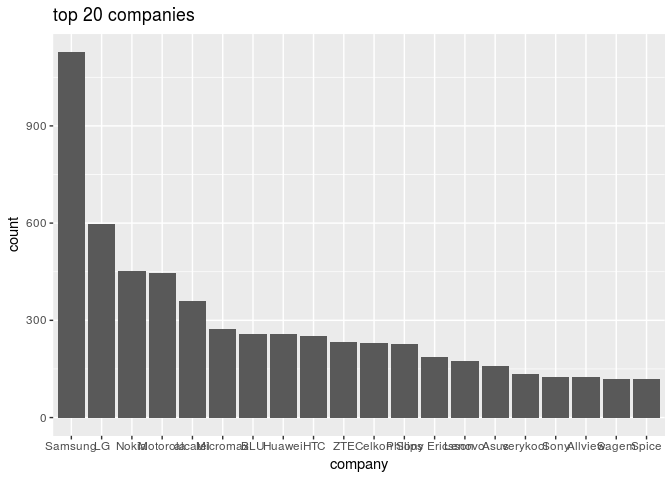

```r
mobile %>% group_by(company) %>%
  summarise(count = n()) %>%
  arrange(desc(count)) %>% head(20) -> stat

ggplot(data=stat, aes(x=reorder(company, -count), y=count)) +
  geom_bar(stat="identity") +
  guides(fill=FALSE) +
  xlab("company") + ylab("count") +
  ggtitle("top 20 companies")
```

۲. نمودار زمانی طول عرض ضخامت و کیفیت دوربین گوشی ها را بکشید و به نمودار هر یک مدل خطی اضافه کنید.

```r
mobile %>%
  filter(!is.na(year)) %>% group_by(year) %>%
  select(dim_length) %>% filter(!is.na(dim_length)) -> stat
```

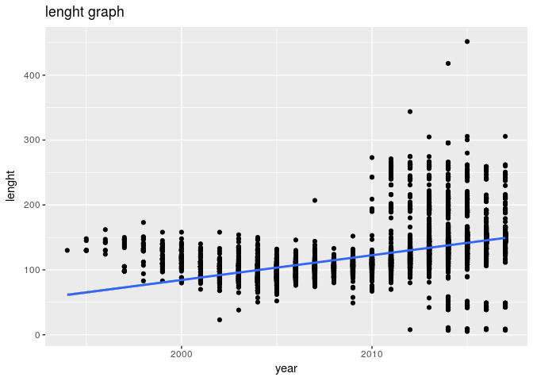

```r
ggplot(stat, aes(x=stat$year, y=stat$dim_length)) +
  geom_point() +
  xlab("year") + ylab("lenght") + ggtitle("lenght graph") +
  geom_smooth(method='lm',formula=y~x)
```

```r
mobile %>%
  filter(!is.na(year)) %>% group_by(year) %>%
  select(dim_breadth) %>% filter(!is.na(dim_breadth)) -> stat
```

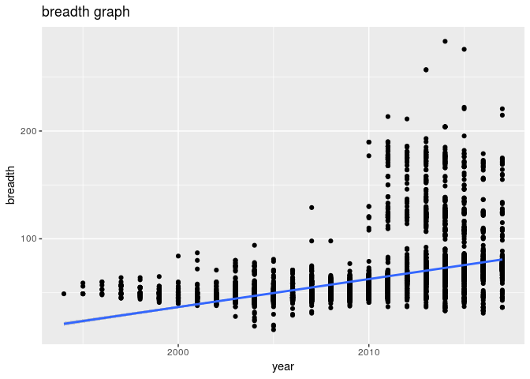

```r
ggplot(stat, aes(x=stat$year, y=stat$dim_breadth)) +
  geom_point() +
  xlab("year") + ylab("breadth") + ggtitle("breadth graph") +
  geom_smooth(method='lm',formula=y~x)
```

```r
mobile %>%
  filter(!is.na(year)) %>% group_by(year) %>%
  select(dim_thickness) %>% filter(!is.na(dim_thickness)) -> stat
```

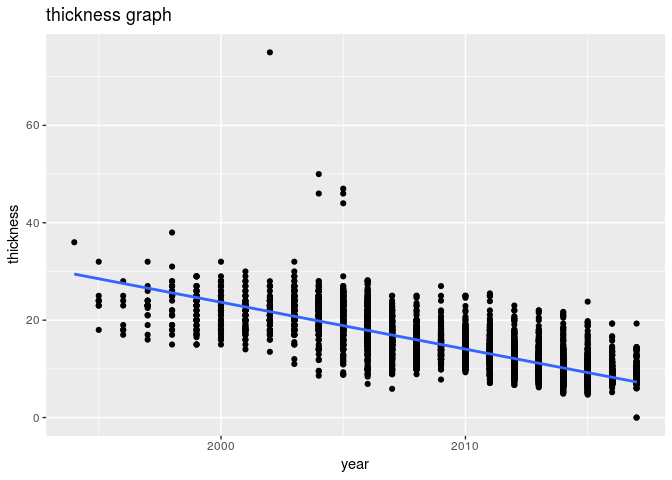

```r
ggplot(stat, aes(x=stat$year, y=stat$dim_thickness)) +
  geom_point() +
  xlab("year") + ylab("thickness") + ggtitle("thickness graph") +
  geom_smooth(method='lm',formula=y~x)
```

```r
mobile %>%
  filter(!is.na(year)) %>% group_by(year) %>%
  select(cam_px) %>% filter(!is.na(cam_px)) -> stat
```

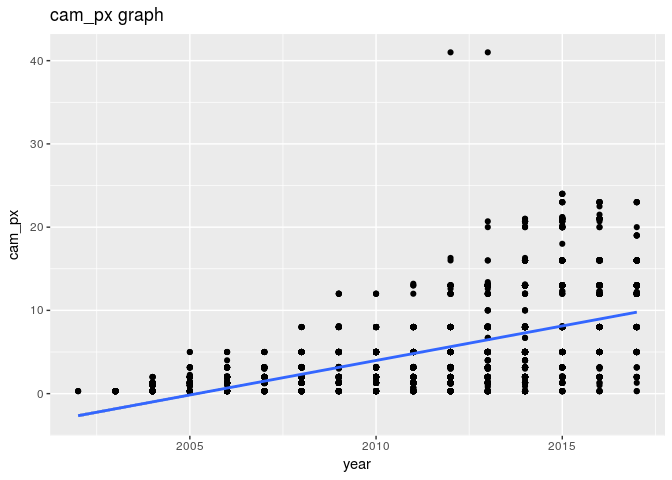

```r
ggplot(stat, aes(x=stat$year, y=stat$cam_px)) +
  geom_point() +
  xlab("year") + ylab("cam_px") + ggtitle("cam_px graph") +
  geom_smooth(method='lm',formula=y~x)
```

۳. نمودار ستونی متوسط قیمت گوشی بر حسب تعداد سیم کارت و دسترسی به LTE را رسم نمایید.

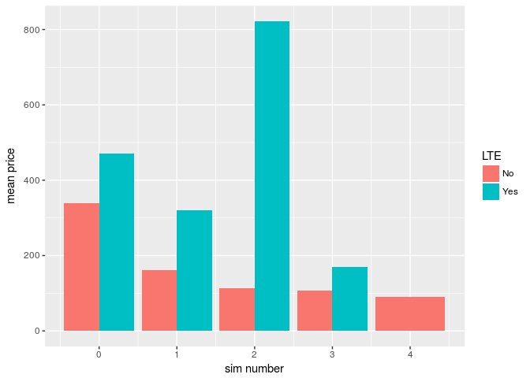

```r
mobile %>%
  group_by(sim_no, LTE) %>% summarise(average = mean(price, na.rm=TRUE)) -> stat

ggplot(stat, aes(fill=LTE, y=average, x=sim_no)) +
  geom_bar(position="dodge", stat="identity") + xlab("sim number") + ylab("mean price")
```

۴. نمودار جعبه ایی ضحامت گوشی هایی که در سال ۲۰۱۷ معرفی شده اند را برحسب اینکه کمیت جک هدفون رسم نمایید

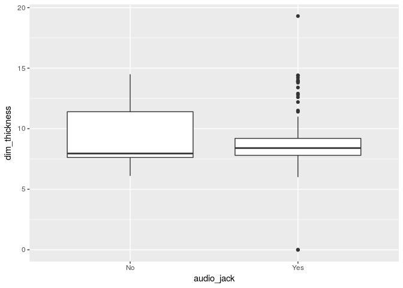

```r
mobile %>%
  filter(year==2017) %>% filter(!is.na(dim_thickness)) %>%
  select(dim_thickness, audio_jack) -> stat

ggplot(stat, aes(x=audio_jack, y=dim_thickness)) + geom_boxplot()
```

۵. مفهوم ppi را در گوشی های موبایل محاسبه و هیستوگرام آن را رسم نمایید. همچنین نمودار سالانه متوسط این کمیت را بکشید. کدام گوشی بیشترین ppi را دارد؟

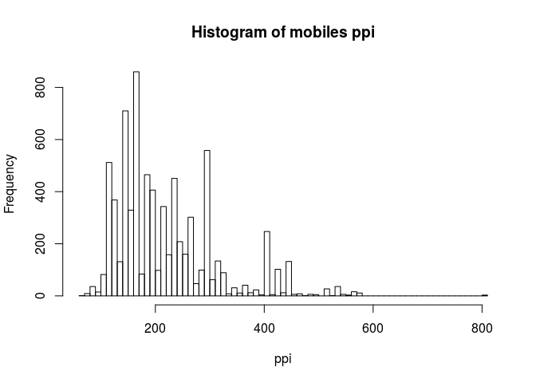

```r
mobile %>%
  filter(!is.na(px_row)) %>% filter(!is.na(px_col)) %>%filter(!is.na(display_size)) %>% filter(!is.na(year)) %>%
  mutate(ppi=sqrt(px_row*px_row + px_col*px_col) / display_size) %>%
  select(year, device, ppi) -> stat

hist(stat$ppi,100, main = "Histogram of mobiles ppi", xlab = 'ppi')
```

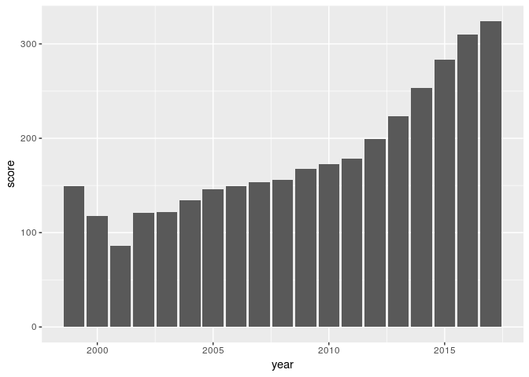

```r
stat %>% group_by(year) %>% summarise(score=mean(ppi)) -> stat1
ggplot(stat1, aes(x=year, y=score)) + geom_bar(stat="identity")
```

```r
max_device_ppi = head(sort(stat$ppi, decreasing = TRUE), 1)
stat %>% filter(ppi==max_device_ppi) %>% select(device)
```

```
## # A tibble: 1 x 1
##   device
##   <chr>
## 1 Xperia XZ Premium
```

۶. در گذشته به بعضی از مدل های گوشی نوکیا **گوشکوب** گفته می شد. سعی کنید برای این مفهوم کمیتی مناسب تعریف کنید . ده گوشکوب برتر را پیدا کرده و نمودار گوشکوبیت آن را رسم نمایید.

```r
#sangin, arzoon, koloft
max_price = head(sort(mobile$price, decreasing = TRUE), 1) + 1
mobile %>%
  filter(!is.na(dim_thickness)) %>% filter(!is.na(weight)) %>% filter(!is.na(price)) %>%
  mutate(score=dim_thickness*weight*((max_price-price)/max_price)) %>% select(device, score, company) %>%
  arrange(desc(score)) %>% head(20) -> stat
stat
```

```
## # A tibble: 20 x 3
##    device             score company
##    <chr>              <dbl> <chr>
##  1 Slate 17           31282 HP
##  2 Shift              19858 HTC
##  3 Toughpad FZ-A1     16437 Panasonic
##  4 Pro Slate 10 EE G1 12212 HP
##  5 Thrive             11482 Toshiba
##  6 Iconia Tab A501    10162 Acer
##  7 TouchPad           10042 HP
##  8 IdeaPad K1          9863 Lenovo
##  9 iPad Wi-Fi + 3G     9646 Apple
## 10 Iconia Tab A500     9643 Acer
## 11 Excite 13 AT335     9601 Toshiba
## 12 Streak 10 Pro       9361 Dell
## 13 XOOM MZ604          9318 Motorola
## 14 XOOM MZ601          9318 Motorola
## 15 XOOM MZ600          9318 Motorola
## 16 Jetstream           9130 HTC
## 17 MC55                9026 Motorola
## 18 iPad Wi-Fi          9016 Apple
## 19 Transformer TF101   8756 Asus
## 20 Iconia Tab A200     8621 Acer
```

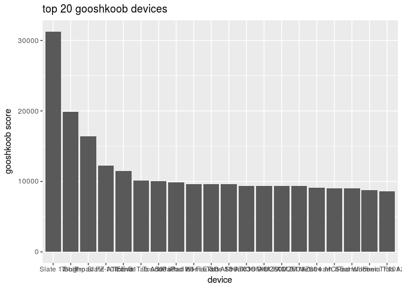

```r
ggplot(stat, aes(x=reorder(device, -score), y=score)) + geom_bar(stat="identity") + xlab("device") + ylab("gooshkoob score") +
  ggtitle("top 20 gooshkoob devices")
```

۷. آیا تلفن همراهی وجود دارد که در آب غرق نشود؟ اگر جواب بله هست تمام گوشی های که این خاصیت را دارند بیابید. با کشیدن یک نمودار به این سوال پاسخ دهید.

```r
mobile %>%
  filter(!is.na(dim_thickness)) %>% filter(!is.na(dim_length)) %>%
  filter(!is.na(dim_breadth)) %>% filter(!is.na(weight)) %>%
  mutate(chegali=weight/(dim_length*dim_breadth*dim_thickness*0.001)) %>%
  filter(chegali < 1) -> stat
stat %>% select(device)
```

```
## # A tibble: 1,014 x 1
##    device
##    <chr>
##  1 2040
##  2 OT-308
##  3 OT-292
##  4 OT-228
##  5 OT-665
##  6 OT-361
##  7 OT-223
##  8 OT-217
##  9 OT-213
## 10 OT-209
## # ... with 1,004 more rows
```

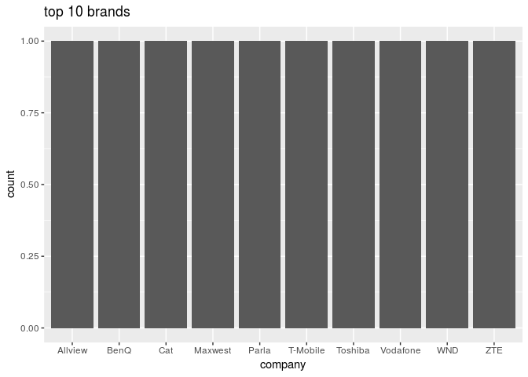

```r
stat %>% group_by(company) %>% summarise(score=n()) %>%
arrange(score) %>% head(10) -> stat1
ggplot(stat1, aes(x=reorder(company, score), y=score)) + geom_bar(stat="identity") + xlab("company") + ylab("count") +
  ggtitle("top 10 brands")
```

۸. نمودار پراکنش حجم ذخیره سازی باطری و وزن را رسم نمایید. میزان همبستگی بین این دو کمیت را محاسبه کنید.

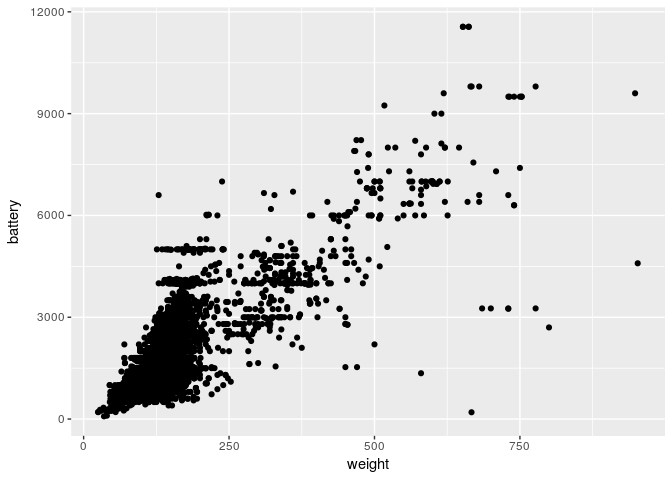

```r
mobile %>%
  filter(!is.na(weight)) %>% filter(!is.na(battery_mah)) %>%
  select(weight, battery_mah) -> stat

ggplot(stat, aes(x=weight, y=battery_mah)) + geom_point() + xlab("weight") + ylab("battery")
```

```r
cor(stat$weight, stat$battery_mah)
```

```
## [1] 0.8086273
```

۹. قیمت پرچمداران یک برند خاص مثلا سامسونگ را بیابید و نمودار قیمت زمان و نام مدل را رسم نمایید.

```r
mobile %>%
  filter(company=='Samsung') %>%
  filter(!is.na(year)) %>% filter(!is.na(price)) %>%
  select(device, contains("Galaxy"), year, price) %>%
  arrange (desc(price)) %>%  head(10) -> stat
stat
```

```
## # A tibble: 10 x 3
##    device                    year price
##    <chr>                    <int> <int>
##  1 Galaxy Note8              2017  1000
##  2 Serenata                  2007  1000
##  3 Galaxy S8 Active          2017   850
##  4 Galaxy Note7              2016   850
##  5 Galaxy Note7 (USA)        2016   760
##  6 Galaxy Tab S3 9.7         2017   750
##  7 S9402 Ego                 2008   690
##  8 Galaxy Round G910S        2013   680
##  9 Galaxy Note Pro 12.2 LTE  2014   670
## 10 Galaxy Note FE            2017   650
```

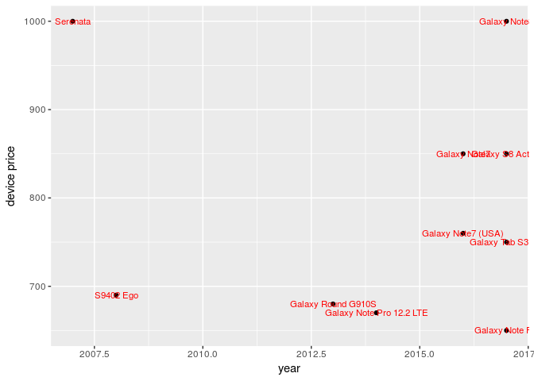

```r
ggplot(stat, aes(x=year, y=price)) +
  geom_point() +
  geom_text(aes(label=device), size=3,color='red') +
  xlab("year") + ylab("device price")
```

۱۰. سه نمودار جالب رسم کنید و توضیح دهید چرا از نظر شما جالب است؟

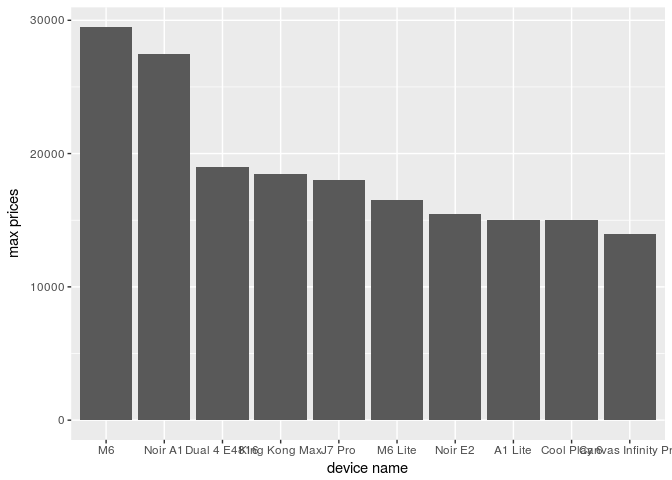

```r
#geroon tarin gooshia
mobile %>%
  filter(!is.na(price)) %>% select(price, device) %>% arrange(-price) %>% head(10) -> stat
ggplot(stat, aes(x=reorder(device, -price), y=price)) + geom_bar(stat="identity") + xlab("device name") + ylab("max prices")
```

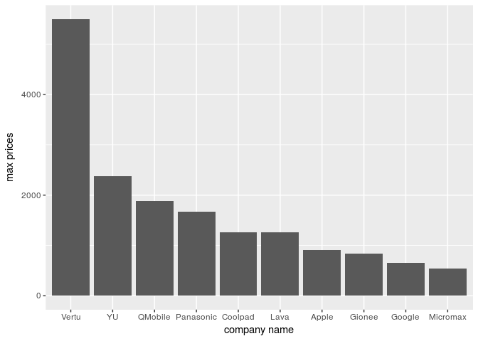

```r
#geroon tarin brand ha
mobile %>%
  filter(!is.na(price)) %>%
  group_by(company) %>% summarise(score=mean(price)) %>% arrange(-score) %>% head(10) -> stat
ggplot(stat, aes(x=reorder(company, -score), y=score)) + geom_bar(stat="identity") + xlab("company name") + ylab("max prices")
```

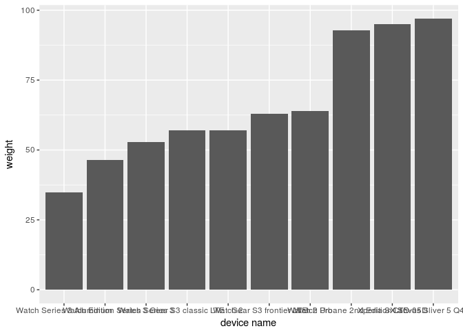

```r
#sabok tarin gooshi ke lte darad
mobile %>%
  filter(!is.na(weight)) %>% filter(!is.na(weight)) %>%
  filter(LTE=='Yes')%>% arrange(weight) %>% head(10) -> stat
ggplot(stat, aes(x=reorder(device, weight), y=weight)) + geom_bar(stat="identity") + xlab("device name") + ylab("weight")
```